# **Project Objective: Dimenshionality Reduction and Analysis**

```python
# improt the necessary libraries
import pandas as pd
import numpy as np
import matplotlib.pyplot as plt
import matplotlib as mpl
import seaborn as sns
from tqdm.auto import tqdm
from tabulate import tabulate
from sklearn.preprocessing import LabelEncoder
from sklearn.decomposition import PCA
from sklearn.preprocessing import StandardScaler
import random
from sklearn.ensemble import ExtraTreesClassifier, RandomForestClassifier, AdaBoostClassifier, GradientBoostingClassifier, BaggingClassifier
from sklearn.neighbors import KNeighborsClassifier
from sklearn.neural_network import MLPClassifier
from sklearn.svm import SVC, LinearSVC
from sklearn.tree import DecisionTreeClassifier
from sklearn.linear_model import LogisticRegression
from xgboost import XGBClassifier
from sklearn.metrics import accuracy_score, precision_score, recall_score, f1_score
from sklearn.metrics import classification_report
from sklearn.metrics import confusion_matrix,ConfusionMatrixDisplay
import time

pd.set_option('display.max_columns', None)

# Ignore warning
import warnings
warnings.filterwarnings('ignore')
```

## **Breast Cancer Wisconsin (Diagnostic) DataSet**

```python
# URL of the dataset on UCI Machine Learning Repository
url = "https://archive.ics.uci.edu/ml/machine-learning-databases/breast-cancer-wisconsin/wdbc.data"

# Define column names for the dataset
column_names = [
    "ID", "Diagnosis", "Mean Radius", "Mean Texture", "Mean Perimeter", "Mean Area", "Mean Smoothness",
    "Mean Compactness", "Mean Concavity", "Mean Concave Points", "Mean Symmetry", "Mean Fractal Dimension",
    "SE Radius", "SE Texture", "SE Perimeter", "SE Area", "SE Smoothness", "SE Compactness", "SE Concavity",
    "SE Concave Points", "SE Symmetry", "SE Fractal Dimension", "Worst Radius", "Worst Texture", "Worst Perimeter",
    "Worst Area", "Worst Smoothness", "Worst Compactness", "Worst Concavity", "Worst Concave Points",
    "Worst Symmetry", "Worst Fractal Dimension"
]

# Load the dataset into a Pandas DataFrame
df = pd.read_csv(url, header=None, names=column_names)

# remove the ID feature that is irrelevent
df = df.drop('ID', axis = 1)

# lets convert the class feature into numeric form
df['Diagnosis'] = df['Diagnosis'].map({'B':0, 'M':1})

df_wdbc = df.copy()
df_wdbc.head()
```

|  | Diagnosis | Mean Radius | Mean Texture | Mean Perimeter | Mean Area | Mean Smoothness | Mean Compactness | Mean Concavity | Mean Concave Points | Mean Symmetry | Mean Fractal Dimension | SE Radius | SE Texture | SE Perimeter | SE Area | SE Smoothness | SE Compactness | SE Concavity | SE Concave Points | SE Symmetry | SE Fractal Dimension | Worst Radius | Worst Texture | Worst Perimeter | Worst Area | Worst Smoothness | Worst Compactness | Worst Concavity | Worst Concave Points | … |
| --- | --- | --- | --- | --- | --- | --- | --- | --- | --- | --- | --- | --- | --- | --- | --- | --- | --- | --- | --- | --- | --- | --- | --- | --- | --- | --- | --- | --- | --- | --- |
| 0 | 1 | 17.99 | 10.38 | 122.80 | 1001.0 | 0.11840 | 0.27760 | 0.3001 | 0.14710 | 0.2419 | 0.07871 | 1.0950 | 0.9053 | 8.589 | 153.40 | 0.006399 | 0.04904 | 0.05373 | 0.01587 | 0.03003 | 0.006193 | 25.38 | 17.33 | 184.60 | 2019.0 | 0.1622 | 0.6656 | 0.7119 | 0.2654 | … |
| 1 | 1 | 20.57 | 17.77 | 132.90 | 1326.0 | 0.08474 | 0.07864 | 0.0869 | 0.07017 | 0.1812 | 0.05667 | 0.5435 | 0.7339 | 3.398 | 74.08 | 0.005225 | 0.01308 | 0.01860 | 0.01340 | 0.01389 | 0.003532 | 24.99 | 23.41 | 158.80 | 1956.0 | 0.1238 | 0.1866 | 0.2416 | 0.1860 | … |
| 2 | 1 | 19.69 | 21.25 | 130.00 | 1203.0 | 0.10960 | 0.15990 | 0.1974 | 0.12790 | 0.2069 | 0.05999 | 0.7456 | 0.7869 | 4.585 | 94.03 | 0.006150 | 0.04006 | 0.03832 | 0.02058 | 0.02250 | 0.004571 | 23.57 | 25.53 | 152.50 | 1709.0 | 0.1444 | 0.4245 | 0.4504 | 0.2430 | … |
| 3 | 1 | 11.42 | 20.38 | 77.58 | 386.1 | 0.14250 | 0.28390 | 0.2414 | 0.10520 | 0.2597 | 0.09744 | 0.4956 | 1.1560 | 3.445 | 27.23 | 0.009110 | 0.07458 | 0.05661 | 0.01867 | 0.05963 | 0.009208 | 14.91 | 26.50 | 98.87 | 567.7 | 0.2098 | 0.8663 | 0.6869 | 0.2575 | … |
| 4 | 1 | 20.29 | 14.34 | 135.10 | 1297.0 | 0.10030 | 0.13280 | 0.1980 | 0.10430 | 0.1809 | 0.05883 | 0.7572 | 0.7813 | 5.438 | 94.44 | 0.011490 | 0.02461 | 0.05688 | 0.01885 | 0.01756 | 0.005115 | 22.54 | 16.67 | 152.20 | 1575.0 | 0.1374 | 0.2050 | 0.4000 | 0.1625 | … |

```python
def check_dataset_shape(df, dataset_name):
  print(f'Total Rows in ({dataset_name}): ', df.shape[0])
  print(f'Total Columns in ({dataset_name}): ', df.shape[1])
  print()
```

```python
check_dataset_shape(df_wdbc, "Breast Cancer Wisconsin DataSet")
```

```
Total Rows in (Breast Cancer Wisconsin DataSet):  569
Total Columns in (Breast Cancer Wisconsin DataSet):  31
```

```python
def target_distribution(df_final, col):
    plt.figure(figsize=(17, 7))

    plt.subplot(1, 2, 1)

    ax = df_final[col].map({0:'B', 1:'M'}).value_counts().plot(kind = 'bar', color = ['green', 'red'])

    plt.xlabel('Target Category', fontsize=16)
    plt.ylabel('Frequency of Target', fontsize=16)
    plt.xticks(size = 12)
    plt.yticks(size = 12)
    plt.title('Frequency Distribution of Target', fontsize=18)
    for p in ax.patches:
        ax.annotate(str(p.get_height()), (p.get_x() * 1.05, p.get_height() * 1.01), size=15)


    plt.subplot(1,2,2)

    df_final[col].map({0:'B', 1:'M'}).value_counts().plot.pie(explode=[0.02,0.02],autopct='%1.2f%%',shadow=True, colors = ['green', 'red'],
                                        textprops={'fontsize':15, 'color':'white'})
    plt.ylabel('target', fontsize=16)
    plt.title('Proportional Distribution of Target', fontsize=18)
    plt.legend()
    plt.show()
```

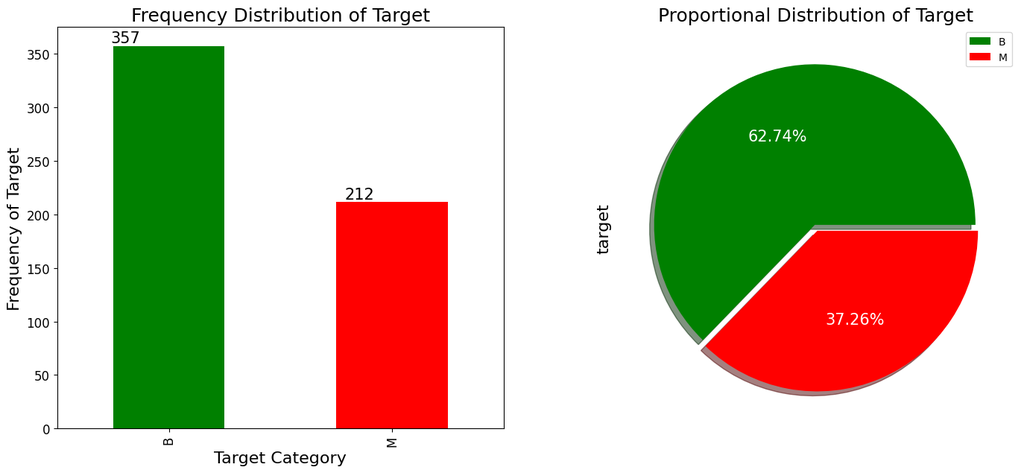

```python
target_distribution(df, "Diagnosis")
```

```python
# WDBC Dataset
X = df_wdbc.drop('Diagnosis', axis = 1)
y = df_wdbc['Diagnosis']
```

## **Normalize the Data**

- Normalization, in the context of data analysis and machine learning, refers to the process of transforming numerical data into a standardized scale. The goal of normalization is to bring different features or variables onto a similar scale to ensure fair comparisons and improve the performance of certain algorithms.

```python
# Normalize the dataset
std = StandardScaler()
X_std = std.fit_transform(X)

df_wdbc_std = pd.DataFrame(X_std, columns=X.columns)
df_wdbc_std_org = df_wdbc_std.copy()
```

## **Split Train Test**

- The purpose of this split is to allow you to train your model on one set of data and then evaluate its performance on another set of data that it hasn't seen before.
- The most common split is a 70/30 or 80/20 split, where the larger portion is used for training the model and the smaller portion is used for evaluating its performance. The training set is used to fit the model to the data, while the testing set is used to evaluate the model's performance in making predictions on new, unseen data.
- **So, we decide to split the dataset, 80% for training and 20% for testing.**

```python
def splitting_dataset(X, y, test_size=0.20):
    from sklearn.model_selection import train_test_split

    assert X.shape[0] == y.shape[0], "Number of samples in X and y should be the same."

    X_train, X_test, y_train, y_test = train_test_split(X, y, test_size=test_size, random_state=0)

    # Check the shape of training and testing sets
    print("Training shape:", X_train.shape)
    print("Testing shape:", X_test.shape)

    return X_train, X_test, y_train, y_test
```

```python
seed = 42
np.random.seed(seed)
random.seed(seed)
```

```python
# lets split the dataset
X_train, X_test, y_train, y_test = splitting_dataset(X_std, y , test_size=0.2)
```

```
Training shape: (455, 30)
Testing shape: (114, 30)
```

**When evaluating the performance of classification, there are several evaluation metrics and techniques you can use. Here are some commonly used ones:**

**Classification Metrics:**

- **Accuracy:** It measures the overall correctness of the classification model by calculating the ratio of correctly classified instances to the total number of instances.
- **Precision:** It measures the proportion of correctly predicted positive instances out of the total instances predicted as positive. It focuses on the quality of the positive predictions.
- **Recall (Sensitivity):** It measures the proportion of correctly predicted positive instances out of the total actual positive instances. It focuses on the coverage of positive instances.
- **F1 Score:** It is the harmonic mean of precision and recall, providing a balanced measure of the model's performance.
- **Classification Report:** It provides a comprehensive summary of the precision, recall, F1 score, and support for each class, giving insights into the performance of the model for each class.
- **Confusion Matrix:** It displays the counts of true positive, false positive, true negative, and false negative predictions, providing a detailed view of the model's performance

```python
def evaluate(model, y_pred, y_test, classes):
    accuracy = round(accuracy_score(y_pred, y_test)*100,2)
    precision = round(precision_score(y_pred, y_test)*100,2)
    recall = round(recall_score(y_pred, y_test)*100,2)
    f1_scr = round(f1_score(y_pred, y_test)*100,2)

    print("Testing Accuracy: {}%".format(accuracy))
    print("Precision: {}%".format(precision))
    print("Recall: {}%".format(recall))
    print("F1-Score: {}%".format(f1_scr))
    print()
    print("Classification Report:")
    print(classification_report(y_pred, y_test, target_names=classes))
    print()
    print("Confusion Matrix:")
    fig, ax = plt.subplots(figsize=(7,5))
    ConfusionMatrixDisplay.from_predictions(y_pred, y_test,
                                            ax=ax,
                                            display_labels=classes,
                                            xticks_rotation='vertical')
    plt.show()

    return pd.DataFrame([{
        'Model':model.__class__.__name__,
        'Accuracy': accuracy,
        'Precision': precision,
        'Recall': recall,
        'F1': f1_scr
    }])
```

```python
def train_model(model,X_test,y_test, classes, technique):
    # Record the start time
    start_time = time.time()

    # Fit the model on the training data
    model.fit(X_train, y_train)

    # Record the end time
    end_time = time.time()

    # Compute the training time in seconds
    training_time = end_time - start_time
    print(f"Training time: {training_time:.3f} seconds")

    # predict the model on testing data
    y_pred = model.predict(X_test)
    y_pred_train = model.predict(X_train)


    # get results
    RESULTS_LR = evaluate(model, y_pred, y_test, classes)

    # Add the training time to RESULTS_LR
    RESULTS_LR['Training time (s)'] = training_time
    RESULTS_LR['Technique'] = technique

    return RESULTS_LR
```

```python
MODELS = {
    'LOGISTIC REGRESSION MODEL': LogisticRegression(),
    'SVC MODEL': SVC(),
    'K NEAREST NEIGHBORS MODEL': KNeighborsClassifier(),
    'MULTILAYER PERCEPTRON MODEL': MLPClassifier(),
    'LINEAR SVC MODEL': LinearSVC(),
    'RANDOM FOREST MODEL': RandomForestClassifier(),
}
```

```
####################################################################################################
				 LOGISTIC REGRESSION MODEL
####################################################################################################
Training time: 0.043 seconds
Testing Accuracy: 96.49%
Precision: 95.74%
Recall: 95.74%
F1-Score: 95.74%

Classification Report:
              precision    recall  f1-score   support

           B       0.97      0.97      0.97        67
           M       0.96      0.96      0.96        47

    accuracy                           0.96       114
   macro avg       0.96      0.96      0.96       114
weighted avg       0.96      0.96      0.96       114


Confusion Matrix:
```

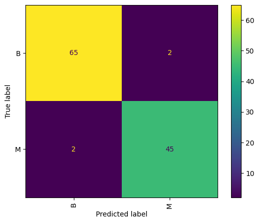

```
####################################################################################################
				 SVC MODEL
####################################################################################################
Training time: 0.008 seconds
Testing Accuracy: 97.37%
Precision: 95.74%
Recall: 97.83%
F1-Score: 96.77%

Classification Report:
              precision    recall  f1-score   support

           B       0.99      0.97      0.98        68
           M       0.96      0.98      0.97        46

    accuracy                           0.97       114
   macro avg       0.97      0.97      0.97       114
weighted avg       0.97      0.97      0.97       114


Confusion Matrix:
```

```
####################################################################################################
				 K NEAREST NEIGHBORS MODEL
####################################################################################################
Training time: 0.001 seconds
Testing Accuracy: 95.61%
Precision: 89.36%
Recall: 100.0%
F1-Score: 94.38%

Classification Report:
              precision    recall  f1-score   support

           B       1.00      0.93      0.96        72
           M       0.89      1.00      0.94        42

    accuracy                           0.96       114
   macro avg       0.95      0.97      0.95       114
weighted avg       0.96      0.96      0.96       114


Confusion Matrix:
```

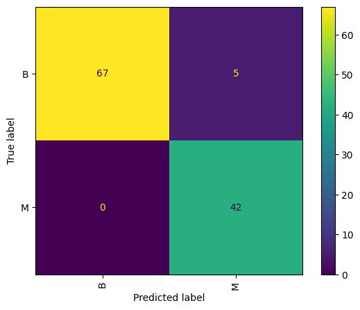

```
####################################################################################################
				 MULTILAYER PERCEPTRON MODEL
####################################################################################################
Training time: 1.509 seconds
Testing Accuracy: 97.37%
Precision: 97.87%
Recall: 95.83%
F1-Score: 96.84%

Classification Report:
              precision    recall  f1-score   support

           B       0.97      0.98      0.98        66
           M       0.98      0.96      0.97        48

    accuracy                           0.97       114
   macro avg       0.97      0.97      0.97       114
weighted avg       0.97      0.97      0.97       114


Confusion Matrix:
```

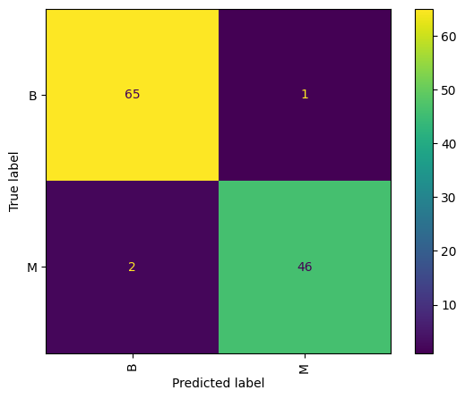

```
####################################################################################################
				 LINEAR SVC MODEL
####################################################################################################
Training time: 0.023 seconds
Testing Accuracy: 94.74%
Precision: 95.74%
Recall: 91.84%
F1-Score: 93.75%

Classification Report:
              precision    recall  f1-score   support

           B       0.94      0.97      0.95        65
           M       0.96      0.92      0.94        49

    accuracy                           0.95       114
   macro avg       0.95      0.94      0.95       114
weighted avg       0.95      0.95      0.95       114


Confusion Matrix:
```

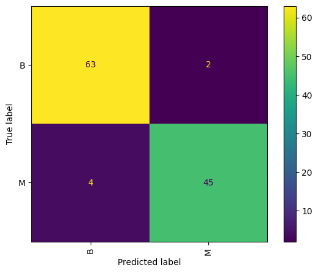

```
####################################################################################################
				 RANDOM FOREST MODEL
####################################################################################################
Training time: 0.356 seconds
Testing Accuracy: 97.37%
Precision: 97.87%
Recall: 95.83%
F1-Score: 96.84%

Classification Report:
              precision    recall  f1-score   support

           B       0.97      0.98      0.98        66
           M       0.98      0.96      0.97        48

    accuracy                           0.97       114
   macro avg       0.97      0.97      0.97       114
weighted avg       0.97      0.97      0.97       114


Confusion Matrix:
```

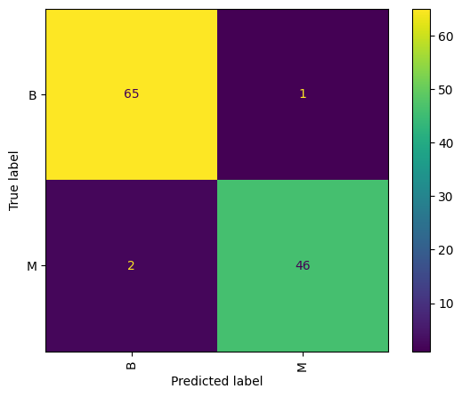

```python
classes = ['B', 'M']
RES = []

for model_name, model in MODELS.items():
  print("#"*100)
  print(f"\t\t\t\t {model_name}")
  print("#"*100)
  res = train_model(model , X_test, y_test,  classes, "All Features")
  RES.append(res)
```

```python
df_all_models = pd.concat(RES)
models_pd_ = df_all_models.reset_index(drop=True)
models_pd_
```

|  | Model | Accuracy | Precision | Recall | F1 | Training time (s) | Technique |
| --- | --- | --- | --- | --- | --- | --- | --- |
| 0 | LogisticRegression | 96.49 | 95.74 | 95.74 | 95.74 | 0.043034 | All Features |
| 1 | SVC | 97.37 | 95.74 | 97.83 | 96.77 | 0.008203 | All Features |
| 2 | KNeighborsClassifier | 95.61 | 89.36 | 100.00 | 94.38 | 0.001170 | All Features |
| 3 | MLPClassifier | 97.37 | 97.87 | 95.83 | 96.84 | 1.508635 | All Features |
| 4 | LinearSVC | 94.74 | 95.74 | 91.84 | 93.75 | 0.022814 | All Features |
| 5 | RandomForestClassifier | 97.37 | 97.87 | 95.83 | 96.84 | 0.356251 | All Features |

## **DIMENSIONALITY REDUCTION**

### **1-Priciple Component Analysis (PCA)**

```python
from sklearn.decomposition import PCA
```

```python
# Dimensionaly Reduction through PCA Wdbc
pca = PCA()
wdbc_pca_reduced = pca.fit_transform(X_std)
```

```python
def plot_cumm_var(pca, dataset_name, threshold=None):
    pc_list = ["PC"+str(i) for i in list(range(1, len(pca.explained_variance_ratio_.tolist())+1))]
    pca_variance = np.cumsum(pca.explained_variance_ratio_.tolist())
    pca_df = pd.DataFrame({'pca_feature':pc_list,'cummulative variance':pca_variance})
    pca_df = pca_df[pca_df['cummulative variance']<=threshold]
    pca_df['cummulative variance'] = round(pca_df['cummulative variance']*100,2)
    # print(tabulate(pca_df, headers = 'keys', tablefmt = 'psql'))
    plt.figure(figsize=(15,5))
    plt.plot(pc_list,pca_variance,c='red',marker='X', linewidth=2,markersize=9)
    if threshold:
        # Draw line set threshold
        value99 = pca_variance[-1]*threshold
        plt.hlines(y = value99, xmin=0, xmax=len(pca.explained_variance_ratio_.tolist()), color = 'r', linestyles = 'dashed')
    plt.title(f"PCA Variance Graph ({dataset_name} Dataset) \n Total Best Feature {len(pca_df)} \n Threshold {threshold}", fontsize=18)
    plt.xlabel("PCs",fontsize=18)
    plt.ylabel("Cummulative Variance",fontsize=18)
    plt.xticks(rotation=90)
    plt.grid(False)  # Remove grid lines
    plt.show()

    print("Final Total Feature We will use for PCA is {}".format(len(pca_df)))
    return len(pca_df)
```

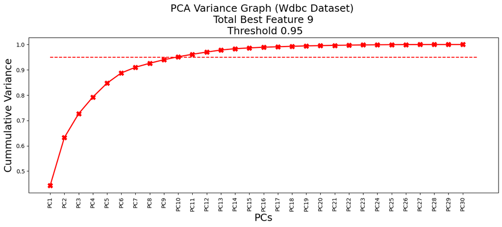

```
Final Total Feature We will use for PCA is 9
```

```python
# lets Draw a horizontal line on the above plot to highlight the threshold of 95%.
nos_pca = plot_cumm_var(pca, 'Wdbc', threshold=0.95)
```

```python
pca1 = PCA(n_components=nos_pca)
wdbc_pca_reduced = pca1.fit_transform(X_std)
```

```python
# lets split the dataset
X_train, X_test, y_train, y_test = splitting_dataset(wdbc_pca_reduced, y , test_size=0.2)
```

```
Training shape: (455, 9)
Testing shape: (114, 9)
```

```
####################################################################################################
				 LOGISTIC REGRESSION MODEL
####################################################################################################
Training time: 0.020 seconds
Testing Accuracy: 94.74%
Precision: 93.62%
Recall: 93.62%
F1-Score: 93.62%

Classification Report:
              precision    recall  f1-score   support

           B       0.96      0.96      0.96        67
           M       0.94      0.94      0.94        47

    accuracy                           0.95       114
   macro avg       0.95      0.95      0.95       114
weighted avg       0.95      0.95      0.95       114


Confusion Matrix:
```

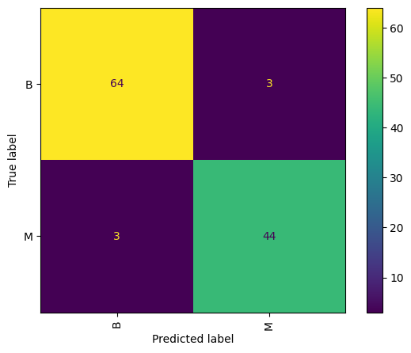

```
####################################################################################################
				 SVC MODEL
####################################################################################################
Training time: 0.008 seconds
Testing Accuracy: 97.37%
Precision: 95.74%
Recall: 97.83%
F1-Score: 96.77%

Classification Report:
              precision    recall  f1-score   support

           B       0.99      0.97      0.98        68
           M       0.96      0.98      0.97        46

    accuracy                           0.97       114
   macro avg       0.97      0.97      0.97       114
weighted avg       0.97      0.97      0.97       114


Confusion Matrix:
```

```
####################################################################################################
				 K NEAREST NEIGHBORS MODEL
####################################################################################################
Training time: 0.004 seconds
Testing Accuracy: 95.61%
Precision: 89.36%
Recall: 100.0%
F1-Score: 94.38%

Classification Report:
              precision    recall  f1-score   support

           B       1.00      0.93      0.96        72
           M       0.89      1.00      0.94        42

    accuracy                           0.96       114
   macro avg       0.95      0.97      0.95       114
weighted avg       0.96      0.96      0.96       114


Confusion Matrix:
```

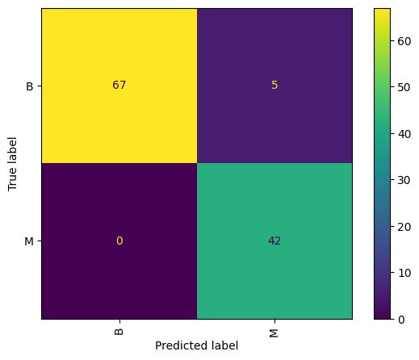

```
####################################################################################################
				 MULTILAYER PERCEPTRON MODEL
####################################################################################################
Training time: 0.629 seconds
Testing Accuracy: 97.37%
Precision: 95.74%
Recall: 97.83%
F1-Score: 96.77%

Classification Report:
              precision    recall  f1-score   support

           B       0.99      0.97      0.98        68
           M       0.96      0.98      0.97        46

    accuracy                           0.97       114
   macro avg       0.97      0.97      0.97       114
weighted avg       0.97      0.97      0.97       114


Confusion Matrix:
```

```
####################################################################################################
				 LINEAR SVC MODEL
####################################################################################################
Training time: 0.010 seconds
Testing Accuracy: 93.86%
Precision: 93.62%
Recall: 91.67%
F1-Score: 92.63%

Classification Report:
              precision    recall  f1-score   support

           B       0.94      0.95      0.95        66
           M       0.94      0.92      0.93        48

    accuracy                           0.94       114
   macro avg       0.94      0.94      0.94       114
weighted avg       0.94      0.94      0.94       114


Confusion Matrix:
```

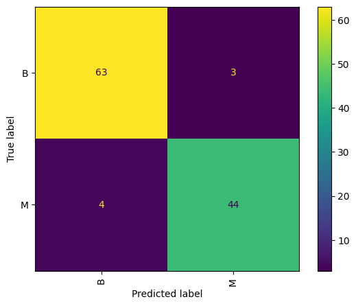

```
####################################################################################################
				 RANDOM FOREST MODEL
####################################################################################################
Training time: 0.209 seconds
Testing Accuracy: 93.86%
Precision: 89.36%
Recall: 95.45%
F1-Score: 92.31%

Classification Report:
              precision    recall  f1-score   support

           B       0.97      0.93      0.95        70
           M       0.89      0.95      0.92        44

    accuracy                           0.94       114
   macro avg       0.93      0.94      0.94       114
weighted avg       0.94      0.94      0.94       114


Confusion Matrix:
```

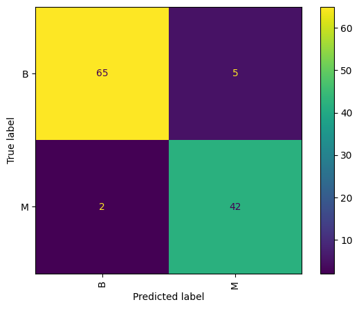

```python
classes = ['B', 'M']
RES = []

for model_name, model in MODELS.items():
  print("#"*100)
  print(f"\t\t\t\t {model_name}")
  print("#"*100)
  res = train_model(model , X_test, y_test,  classes, "PCA")
  RES.append(res)
```

```python
df_all_models = pd.concat(RES)
models_pd_pca = df_all_models.reset_index(drop=True)
models_pd_pca
```

|  | Model | Accuracy | Precision | Recall | F1 | Training time (s) | Technique |
| --- | --- | --- | --- | --- | --- | --- | --- |
| 0 | LogisticRegression | 94.74 | 93.62 | 93.62 | 93.62 | 0.019762 | PCA |
| 1 | SVC | 97.37 | 95.74 | 97.83 | 96.77 | 0.008122 | PCA |
| 2 | KNeighborsClassifier | 95.61 | 89.36 | 100.00 | 94.38 | 0.003553 | PCA |
| 3 | MLPClassifier | 97.37 | 95.74 | 97.83 | 96.77 | 0.629184 | PCA |
| 4 | LinearSVC | 93.86 | 93.62 | 91.67 | 92.63 | 0.009651 | PCA |
| 5 | RandomForestClassifier | 93.86 | 89.36 | 95.45 | 92.31 | 0.209383 | PCA |

### **2-Independent Component Analysis (ICA)**

```python
from sklearn.decomposition import FastICA
from scipy.stats import kurtosis

ica = FastICA(random_state=42)
S_ = ica.fit_transform(X_std)
```

```python
def plot_ICA_check_Components(df,ica_data, dataset_name):
  # Compute kurtosis for each component
  kurtosis_values = kurtosis(ica_data)
  # Sort the kurtosis values in descending order
  sorted_kurtosis = np.sort(kurtosis_values)[::-1]

  # Calculate the cumulative variance explained by each component
  cumulative_kurtosis = np.cumsum(sorted_kurtosis) / np.sum(sorted_kurtosis)

  # Scree plot
  explained_variance_ratio = np.var(ica_data, axis=0) / np.var(df.values, axis=0)
  cumulative_explained_variance = np.cumsum(explained_variance_ratio)

  # Information criteria (AIC and BIC)
  n_components = np.arange(1, len(kurtosis_values) + 1)
  aic = []
  bic = []
  for n in n_components:
      aic_value = 2 * n - 2 * np.sum(np.log(np.abs(kurtosis_values[:n])))
      bic_value = n * np.log(df.shape[1]) - 2 * np.sum(np.log(np.abs(kurtosis_values[:n])))
      aic.append(aic_value)
      bic.append(bic_value)


  # Plotting
  plt.figure(figsize=(12, 5))

  # Scree plot
  plt.subplot(1, 3, 1)
  plt.plot(n_components, cumulative_explained_variance, marker='o')
  plt.xlabel("Number of Components")
  plt.ylabel("Cumulative Explained Variance")
  plt.title(f"Scree Plot\n{dataset_name} Dataset")
  plt.grid(False)  # Remove grid lines

  # Kurtosis
  plt.subplot(1, 3, 2)
  plt.plot(range(1, len(sorted_kurtosis) + 1), cumulative_kurtosis, marker='o')
  plt.xlabel("Number of Components")
  plt.ylabel("Cumulative Kurtosis")
  plt.title(f"Cumulative Kurtosis\n{dataset_name} Dataset")
  plt.grid(False)  # Remove grid lines

  # AIC and BIC
  plt.subplot(1, 3, 3)
  plt.plot(n_components, aic, marker='o', label='AIC')
  plt.plot(n_components, bic, marker='o', label='BIC')
  plt.xlabel("Number of Components")
  plt.ylabel("Information Criteria Value")
  plt.title(f"Information Criteria (AIC and BIC)\n{dataset_name} Dataset")
  plt.grid(False)  # Remove grid lines
  plt.legend()

  plt.tight_layout()
  plt.show()
```

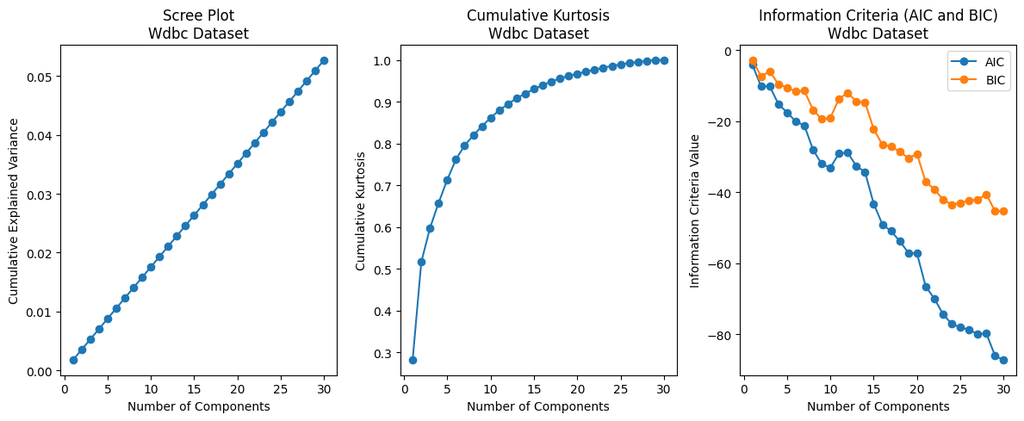

```python
plot_ICA_check_Components(df_wdbc_std, S_, 'Wdbc')
```

**Based on kurtosis analysis/Scree Plot/BIC:**

- For the **Wisconsin dataset**, it is recommended to choose 10 components using kurtosis analysis. This number appears to capture the most non-Gaussian and independent features in the dataset, making it suitable for dimensionality reduction or further analysis.

```python
ica = FastICA(n_components=10, random_state=42)
W_ = ica.fit_transform(df_wdbc_std)
```

```python
# lets split the dataset
X_train, X_test, y_train, y_test = splitting_dataset(W_, y , test_size=0.2)
```

```
Training shape: (455, 10)
Testing shape: (114, 10)
```

```
####################################################################################################
				 LOGISTIC REGRESSION MODEL
####################################################################################################
Training time: 0.006 seconds
Testing Accuracy: 61.4%
Precision: 6.38%
Recall: 100.0%
F1-Score: 12.0%

Classification Report:
              precision    recall  f1-score   support

           B       1.00      0.60      0.75       111
           M       0.06      1.00      0.12         3

    accuracy                           0.61       114
   macro avg       0.53      0.80      0.44       114
weighted avg       0.98      0.61      0.74       114


Confusion Matrix:
```

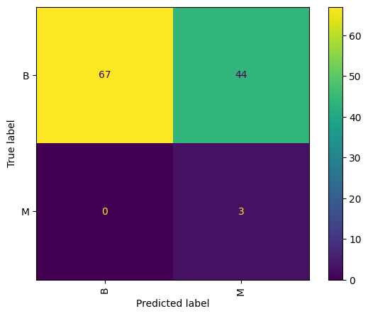

```
####################################################################################################
				 SVC MODEL
####################################################################################################
Training time: 0.014 seconds
Testing Accuracy: 93.86%
Precision: 89.36%
Recall: 95.45%
F1-Score: 92.31%

Classification Report:
              precision    recall  f1-score   support

           B       0.97      0.93      0.95        70
           M       0.89      0.95      0.92        44

    accuracy                           0.94       114
   macro avg       0.93      0.94      0.94       114
weighted avg       0.94      0.94      0.94       114


Confusion Matrix:
```

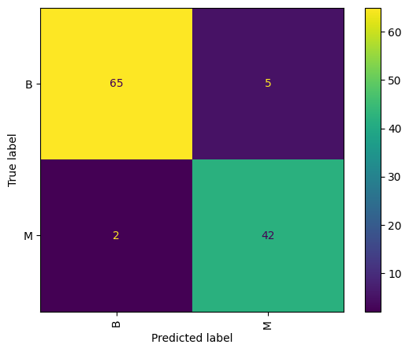

```
####################################################################################################
				 K NEAREST NEIGHBORS MODEL
####################################################################################################
Training time: 0.003 seconds
Testing Accuracy: 87.72%
Precision: 74.47%
Recall: 94.59%
F1-Score: 83.33%

Classification Report:
              precision    recall  f1-score   support

           B       0.97      0.84      0.90        77
           M       0.74      0.95      0.83        37

    accuracy                           0.88       114
   macro avg       0.86      0.90      0.87       114
weighted avg       0.90      0.88      0.88       114


Confusion Matrix:
```

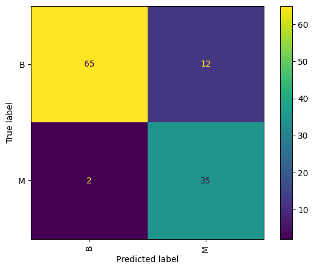

```
####################################################################################################
				 MULTILAYER PERCEPTRON MODEL
####################################################################################################
Training time: 1.703 seconds
Testing Accuracy: 93.86%
Precision: 85.11%
Recall: 100.0%
F1-Score: 91.95%

Classification Report:
              precision    recall  f1-score   support

           B       1.00      0.91      0.95        74
           M       0.85      1.00      0.92        40

    accuracy                           0.94       114
   macro avg       0.93      0.95      0.93       114
weighted avg       0.95      0.94      0.94       114


Confusion Matrix:
```

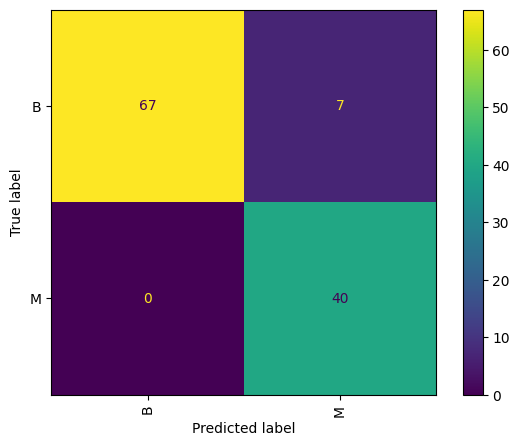

```
####################################################################################################
				 LINEAR SVC MODEL
####################################################################################################
Training time: 0.006 seconds
Testing Accuracy: 93.86%
Precision: 85.11%
Recall: 100.0%
F1-Score: 91.95%

Classification Report:
              precision    recall  f1-score   support

           B       1.00      0.91      0.95        74
           M       0.85      1.00      0.92        40

    accuracy                           0.94       114
   macro avg       0.93      0.95      0.93       114
weighted avg       0.95      0.94      0.94       114


Confusion Matrix:
```

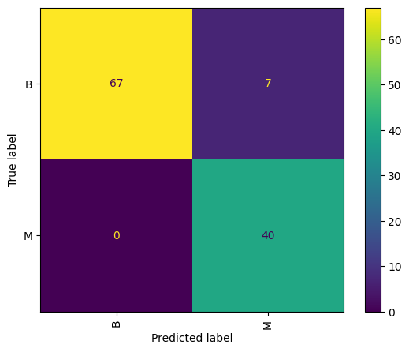

```
####################################################################################################
				 RANDOM FOREST MODEL
####################################################################################################
Training time: 0.875 seconds
Testing Accuracy: 92.11%
Precision: 82.98%
Recall: 97.5%
F1-Score: 89.66%

Classification Report:
              precision    recall  f1-score   support

           B       0.99      0.89      0.94        74
           M       0.83      0.97      0.90        40

    accuracy                           0.92       114
   macro avg       0.91      0.93      0.92       114
weighted avg       0.93      0.92      0.92       114


Confusion Matrix:
```

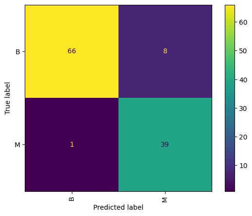

```python
classes = ['B', 'M']
RES = []

for model_name, model in MODELS.items():
  print("#"*100)
  print(f"\t\t\t\t {model_name}")
  print("#"*100)
  res = train_model(model , X_test, y_test,  classes, "ICA")
  RES.append(res)
```

```python
df_all_models = pd.concat(RES)
models_pd_ica = df_all_models.reset_index(drop=True)
models_pd_ica
```

|  | Model | Accuracy | Precision | Recall | F1 | Training time (s) | Technique |
| --- | --- | --- | --- | --- | --- | --- | --- |
| 0 | LogisticRegression | 61.40 | 6.38 | 100.00 | 12.00 | 0.006219 | ICA |
| 1 | SVC | 93.86 | 89.36 | 95.45 | 92.31 | 0.013596 | ICA |
| 2 | KNeighborsClassifier | 87.72 | 74.47 | 94.59 | 83.33 | 0.002717 | ICA |
| 3 | MLPClassifier | 93.86 | 85.11 | 100.00 | 91.95 | 1.703456 | ICA |
| 4 | LinearSVC | 93.86 | 85.11 | 100.00 | 91.95 | 0.005539 | ICA |
| 5 | RandomForestClassifier | 92.11 | 82.98 | 97.50 | 89.66 | 0.875021 | ICA |

### **3-Randomized Projections (RP)**

```python
from sklearn.random_projection import GaussianRandomProjection
from sklearn.metrics import mean_squared_error
```

```python
def plot_RP_check_Components(X, dataset_name):
  recons_err = []
  fit_time = []
  # max components = no features
  comp = range(1, X.shape[1])

  for i in comp:
    grp = GaussianRandomProjection(n_components = i, random_state=42)
    grp.fit(X)
    # Calculate recons err
    trans = grp.transform(X)
    pinv = np.linalg.pinv(np.transpose(grp.components_))
    X_recons = np.dot(trans, pinv)
    X_recons = pd.DataFrame(data=X_recons, columns=X.columns)
    rmse = np.sqrt(mean_squared_error(X, X_recons))
    recons_err.append(rmse)
  # print(recons_err)
  plt.figure(figsize=(6,5))
  # Plot ICA
  plt.plot(comp,recons_err, marker='o')
  plt.title(f'Randomized Projections - {dataset_name} Dataset')
  plt.xlabel('Number of components')
  plt.ylabel('Reconstruction error (RMSE)')
  #plt.legend(loc='best')
  plt.grid()
  plt.show()
```

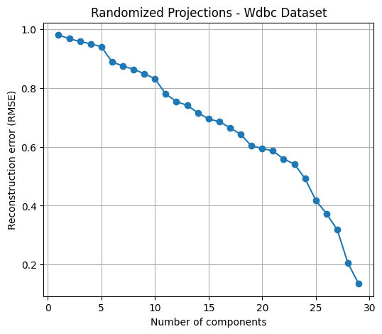

```python
plot_RP_check_Components(df_wdbc_std, 'Wdbc')
```

```python
rp = GaussianRandomProjection(n_components=10, random_state=42)
W_RP = rp.fit_transform(df_wdbc_std)
```

```python
# lets split the dataset
X_train, X_test, y_train, y_test = splitting_dataset(W_RP, y , test_size=0.2)
```

```
Training shape: (455, 10)
Testing shape: (114, 10)
```

```
####################################################################################################
				 LOGISTIC REGRESSION MODEL
####################################################################################################
Training time: 0.015 seconds
Testing Accuracy: 95.61%
Precision: 95.74%
Recall: 93.75%
F1-Score: 94.74%

Classification Report:
              precision    recall  f1-score   support

           B       0.96      0.97      0.96        66
           M       0.96      0.94      0.95        48

    accuracy                           0.96       114
   macro avg       0.96      0.95      0.95       114
weighted avg       0.96      0.96      0.96       114


Confusion Matrix:
```

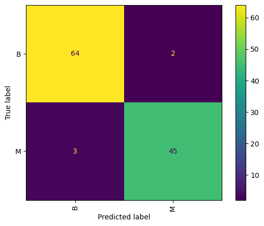

```
####################################################################################################
				 SVC MODEL
####################################################################################################
Training time: 0.009 seconds
Testing Accuracy: 95.61%
Precision: 93.62%
Recall: 95.65%
F1-Score: 94.62%

Classification Report:
              precision    recall  f1-score   support

           B       0.97      0.96      0.96        68
           M       0.94      0.96      0.95        46

    accuracy                           0.96       114
   macro avg       0.95      0.96      0.95       114
weighted avg       0.96      0.96      0.96       114


Confusion Matrix:
```

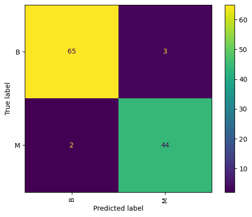

```
####################################################################################################
				 K NEAREST NEIGHBORS MODEL
####################################################################################################
Training time: 0.002 seconds
Testing Accuracy: 93.86%
Precision: 87.23%
Recall: 97.62%
F1-Score: 92.13%

Classification Report:
              precision    recall  f1-score   support

           B       0.99      0.92      0.95        72
           M       0.87      0.98      0.92        42

    accuracy                           0.94       114
   macro avg       0.93      0.95      0.94       114
weighted avg       0.94      0.94      0.94       114


Confusion Matrix:
```

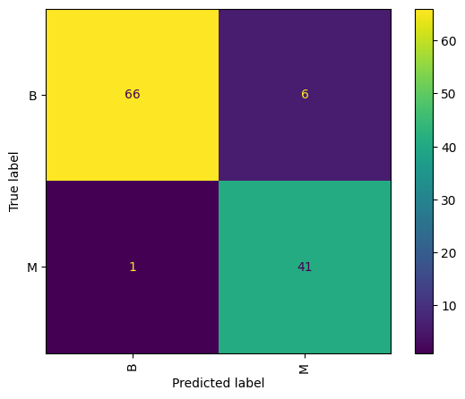

```
####################################################################################################
				 MULTILAYER PERCEPTRON MODEL
####################################################################################################
Training time: 1.769 seconds
Testing Accuracy: 94.74%
Precision: 95.74%
Recall: 91.84%
F1-Score: 93.75%

Classification Report:
              precision    recall  f1-score   support

           B       0.94      0.97      0.95        65
           M       0.96      0.92      0.94        49

    accuracy                           0.95       114
   macro avg       0.95      0.94      0.95       114
weighted avg       0.95      0.95      0.95       114


Confusion Matrix:
```

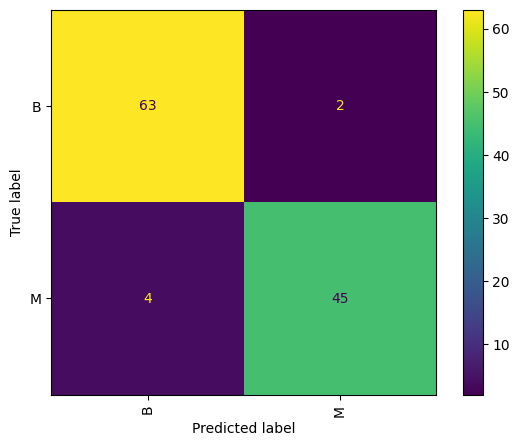

```
####################################################################################################
				 LINEAR SVC MODEL
####################################################################################################
Training time: 0.008 seconds
Testing Accuracy: 95.61%
Precision: 97.87%
Recall: 92.0%
F1-Score: 94.85%

Classification Report:
              precision    recall  f1-score   support

           B       0.94      0.98      0.96        64
           M       0.98      0.92      0.95        50

    accuracy                           0.96       114
   macro avg       0.96      0.95      0.96       114
weighted avg       0.96      0.96      0.96       114


Confusion Matrix:
```

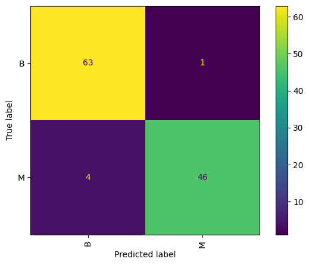

```
####################################################################################################
				 RANDOM FOREST MODEL
####################################################################################################
Training time: 0.810 seconds
Testing Accuracy: 94.74%
Precision: 91.49%
Recall: 95.56%
F1-Score: 93.48%

Classification Report:
              precision    recall  f1-score   support

           B       0.97      0.94      0.96        69
           M       0.91      0.96      0.93        45

    accuracy                           0.95       114
   macro avg       0.94      0.95      0.95       114
weighted avg       0.95      0.95      0.95       114


Confusion Matrix:
```

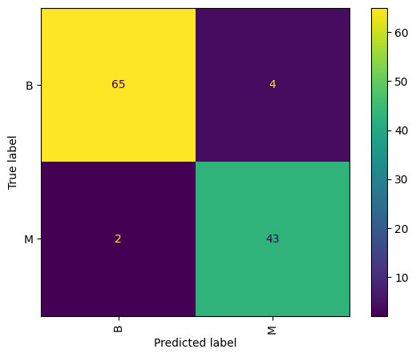

```python
classes = ['B', 'M']
RES = []

for model_name, model in MODELS.items():
  print("#"*100)
  print(f"\t\t\t\t {model_name}")
  print("#"*100)
  res = train_model(model , X_test, y_test,  classes, "RP")
  RES.append(res)
```

```python
df_all_models = pd.concat(RES)
models_pd_rp = df_all_models.reset_index(drop=True)
models_pd_rp
```

|  | Model | Accuracy | Precision | Recall | F1 | Training time (s) | Technique |
| --- | --- | --- | --- | --- | --- | --- | --- |
| 0 | LogisticRegression | 95.61 | 95.74 | 93.75 | 94.74 | 0.014628 | RP |
| 1 | SVC | 95.61 | 93.62 | 95.65 | 94.62 | 0.008935 | RP |
| 2 | KNeighborsClassifier | 93.86 | 87.23 | 97.62 | 92.13 | 0.001889 | RP |
| 3 | MLPClassifier | 94.74 | 95.74 | 91.84 | 93.75 | 1.768658 | RP |
| 4 | LinearSVC | 95.61 | 97.87 | 92.00 | 94.85 | 0.008339 | RP |
| 5 | RandomForestClassifier | 94.74 | 91.49 | 95.56 | 93.48 | 0.810257 | RP |

### **4 - Linear Discriminant Analysis (LDA)**

- LDA is another dimensionality reduction. Like PCA, it involves projecting the data onto axes; however, its goal is to choose axes that maximize class separability and minimize intra-class scatter simultaneously. With a binary-class dataset, the data will be projected onto a line. With a n-class dataset, the data will be projected onto an (n-1)-dimensional-space.

```python
from sklearn.discriminant_analysis import LinearDiscriminantAnalysis
```

```python
# Initialize LDA and fit-transform for different numbers of components
lda = LinearDiscriminantAnalysis(n_components = 1) # n_components in this case is 1 less than the number of classes.
X_lda = lda.fit_transform(X, y)
```

```python
# lets split the dataset
X_train, X_test, y_train, y_test = splitting_dataset(X_lda, y , test_size=0.2)
```

```
Training shape: (455, 1)
Testing shape: (114, 1)
```

```python
classes = ['B', 'M']
RES = []

for model_name, model in MODELS.items():
  print("#"*100)
  print(f"\t\t\t\t {model_name}")
  print("#"*100)
  res = train_model(model , X_test, y_test,  classes, "LDA")
  RES.append(res)
```

```
####################################################################################################
				 LOGISTIC REGRESSION MODEL
####################################################################################################
Training time: 0.016 seconds
Testing Accuracy: 97.37%
Precision: 95.74%
Recall: 97.83%
F1-Score: 96.77%

Classification Report:
              precision    recall  f1-score   support

           B       0.99      0.97      0.98        68
           M       0.96      0.98      0.97        46

    accuracy                           0.97       114
   macro avg       0.97      0.97      0.97       114
weighted avg       0.97      0.97      0.97       114


Confusion Matrix:
```

```
####################################################################################################
				 SVC MODEL
####################################################################################################
Training time: 0.005 seconds
Testing Accuracy: 97.37%
Precision: 95.74%
Recall: 97.83%
F1-Score: 96.77%

Classification Report:
              precision    recall  f1-score   support

           B       0.99      0.97      0.98        68
           M       0.96      0.98      0.97        46

    accuracy                           0.97       114
   macro avg       0.97      0.97      0.97       114
weighted avg       0.97      0.97      0.97       114


Confusion Matrix:
```

```
####################################################################################################
				 K NEAREST NEIGHBORS MODEL
####################################################################################################
Training time: 0.003 seconds
Testing Accuracy: 97.37%
Precision: 95.74%
Recall: 97.83%
F1-Score: 96.77%

Classification Report:
              precision    recall  f1-score   support

           B       0.99      0.97      0.98        68
           M       0.96      0.98      0.97        46

    accuracy                           0.97       114
   macro avg       0.97      0.97      0.97       114
weighted avg       0.97      0.97      0.97       114


Confusion Matrix:
```

```
####################################################################################################
				 MULTILAYER PERCEPTRON MODEL
####################################################################################################
Training time: 1.258 seconds
Testing Accuracy: 97.37%
Precision: 95.74%
Recall: 97.83%
F1-Score: 96.77%

Classification Report:
              precision    recall  f1-score   support

           B       0.99      0.97      0.98        68
           M       0.96      0.98      0.97        46

    accuracy                           0.97       114
   macro avg       0.97      0.97      0.97       114
weighted avg       0.97      0.97      0.97       114


Confusion Matrix:
```

```
####################################################################################################
				 LINEAR SVC MODEL
####################################################################################################
Training time: 0.012 seconds
Testing Accuracy: 97.37%
Precision: 95.74%
Recall: 97.83%
F1-Score: 96.77%

Classification Report:
              precision    recall  f1-score   support

           B       0.99      0.97      0.98        68
           M       0.96      0.98      0.97        46

    accuracy                           0.97       114
   macro avg       0.97      0.97      0.97       114
weighted avg       0.97      0.97      0.97       114


Confusion Matrix:
```

```
####################################################################################################
				 RANDOM FOREST MODEL
####################################################################################################
Training time: 0.842 seconds
Testing Accuracy: 97.37%
Precision: 95.74%
Recall: 97.83%
F1-Score: 96.77%

Classification Report:
              precision    recall  f1-score   support

           B       0.99      0.97      0.98        68
           M       0.96      0.98      0.97        46

    accuracy                           0.97       114
   macro avg       0.97      0.97      0.97       114
weighted avg       0.97      0.97      0.97       114


Confusion Matrix:
```

```python
df_all_models = pd.concat(RES)
models_pd_lda = df_all_models.reset_index(drop=True)
models_pd_lda
```

|  | Model | Accuracy | Precision | Recall | F1 | Training time (s) | Technique |
| --- | --- | --- | --- | --- | --- | --- | --- |
| 0 | LogisticRegression | 97.37 | 95.74 | 97.83 | 96.77 | 0.016055 | LDA |
| 1 | SVC | 97.37 | 95.74 | 97.83 | 96.77 | 0.004918 | LDA |
| 2 | KNeighborsClassifier | 97.37 | 95.74 | 97.83 | 96.77 | 0.003254 | LDA |
| 3 | MLPClassifier | 97.37 | 95.74 | 97.83 | 96.77 | 1.258081 | LDA |
| 4 | LinearSVC | 97.37 | 95.74 | 97.83 | 96.77 | 0.011935 | LDA |
| 5 | RandomForestClassifier | 97.37 | 95.74 | 97.83 | 96.77 | 0.841808 | LDA |

## **Evaluations**

```python
df_final_ = pd.concat([models_pd_, models_pd_pca, models_pd_ica, models_pd_rp, models_pd_lda]).reset_index(drop=True)
df_final_
```

|  | Model | Accuracy | Precision | Recall | F1 | Training time (s) | Technique |
| --- | --- | --- | --- | --- | --- | --- | --- |
| 0 | LogisticRegression | 96.49 | 95.74 | 95.74 | 95.74 | 0.043034 | All Features |
| 1 | SVC | 97.37 | 95.74 | 97.83 | 96.77 | 0.008203 | All Features |
| 2 | KNeighborsClassifier | 95.61 | 89.36 | 100.00 | 94.38 | 0.001170 | All Features |
| 3 | MLPClassifier | 97.37 | 97.87 | 95.83 | 96.84 | 1.508635 | All Features |
| 4 | LinearSVC | 94.74 | 95.74 | 91.84 | 93.75 | 0.022814 | All Features |
| 5 | RandomForestClassifier | 97.37 | 97.87 | 95.83 | 96.84 | 0.356251 | All Features |
| 6 | LogisticRegression | 94.74 | 93.62 | 93.62 | 93.62 | 0.019762 | PCA |
| 7 | SVC | 97.37 | 95.74 | 97.83 | 96.77 | 0.008122 | PCA |
| 8 | KNeighborsClassifier | 95.61 | 89.36 | 100.00 | 94.38 | 0.003553 | PCA |
| 9 | MLPClassifier | 97.37 | 95.74 | 97.83 | 96.77 | 0.629184 | PCA |
| 10 | LinearSVC | 93.86 | 93.62 | 91.67 | 92.63 | 0.009651 | PCA |
| 11 | RandomForestClassifier | 93.86 | 89.36 | 95.45 | 92.31 | 0.209383 | PCA |
| 12 | LogisticRegression | 61.40 | 6.38 | 100.00 | 12.00 | 0.006219 | ICA |
| 13 | SVC | 93.86 | 89.36 | 95.45 | 92.31 | 0.013596 | ICA |
| 14 | KNeighborsClassifier | 87.72 | 74.47 | 94.59 | 83.33 | 0.002717 | ICA |
| 15 | MLPClassifier | 93.86 | 85.11 | 100.00 | 91.95 | 1.703456 | ICA |
| 16 | LinearSVC | 93.86 | 85.11 | 100.00 | 91.95 | 0.005539 | ICA |
| 17 | RandomForestClassifier | 92.11 | 82.98 | 97.50 | 89.66 | 0.875021 | ICA |
| 18 | LogisticRegression | 95.61 | 95.74 | 93.75 | 94.74 | 0.014628 | RP |
| 19 | SVC | 95.61 | 93.62 | 95.65 | 94.62 | 0.008935 | RP |
| 20 | KNeighborsClassifier | 93.86 | 87.23 | 97.62 | 92.13 | 0.001889 | RP |
| 21 | MLPClassifier | 94.74 | 95.74 | 91.84 | 93.75 | 1.768658 | RP |
| 22 | LinearSVC | 95.61 | 97.87 | 92.00 | 94.85 | 0.008339 | RP |
| 23 | RandomForestClassifier | 94.74 | 91.49 | 95.56 | 93.48 | 0.810257 | RP |
| 24 | LogisticRegression | 97.37 | 95.74 | 97.83 | 96.77 | 0.016055 | LDA |
| 25 | SVC | 97.37 | 95.74 | 97.83 | 96.77 | 0.004918 | LDA |
| 26 | KNeighborsClassifier | 97.37 | 95.74 | 97.83 | 96.77 | 0.003254 | LDA |
| 27 | MLPClassifier | 97.37 | 95.74 | 97.83 | 96.77 | 1.258081 | LDA |
| 28 | LinearSVC | 97.37 | 95.74 | 97.83 | 96.77 | 0.011935 | LDA |
| 29 | RandomForestClassifier | 97.37 | 95.74 | 97.83 | 96.77 | 0.841808 | LDA |

Based on the provided data, let's discuss which reduction technique gives better results.

Overall, based on the provided results, LDA seems to be the most effective dimensionality reduction technique, as it consistently maintains high accuracy and precision across different models. PCA also performs well and significantly reduces the feature space, making it a good option when dimensionality reduction is desired. RP shows mixed results, while ICA performs relatively poorly compared to the other techniques. It's important to note that the performance of dimensionality reduction techniques can vary depending on the dataset and the specific problem at hand. It's recommended to experiment with different techniques and evaluate their performance on specific tasks to determine the most suitable approach.

```python
def plot_graph(df,  metrics='Accuracy'):
  # Plotting using Seaborn
  plt.figure(figsize=(12, 8))
  ax = sns.barplot(x='Model', y=metrics, hue='Technique', data=df)

  # Annotate with count text
  for p in ax.patches:
      ax.annotate(f'{p.get_height():.2f}',
                  (p.get_x() + p.get_width() / 2., p.get_height()),
                  ha='center', va='center', fontsize=8, color='black', xytext=(0, 5),
                  textcoords='offset points')

  plt.xlabel('Model')
  plt.ylabel('Accuracy')
  plt.title(f'Model {metrics} for Different Techniques')
  plt.xticks(rotation=90)  # Rotating x-axis labels for better readability
  plt.legend(title='Technique', bbox_to_anchor=(1, 1), loc='upper left')
  plt.tight_layout()
  plt.show()
```

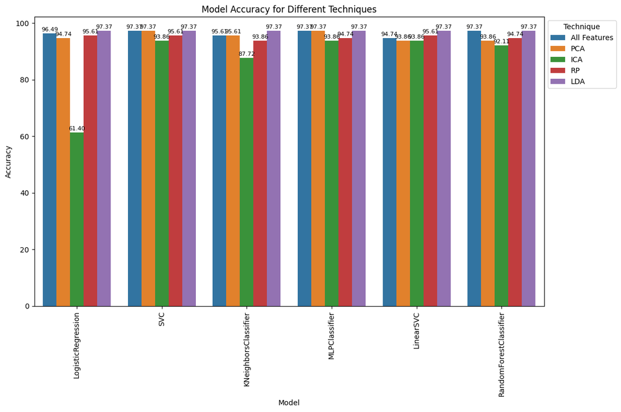

```python
plot_graph(df_final_,  metrics='Accuracy')
```

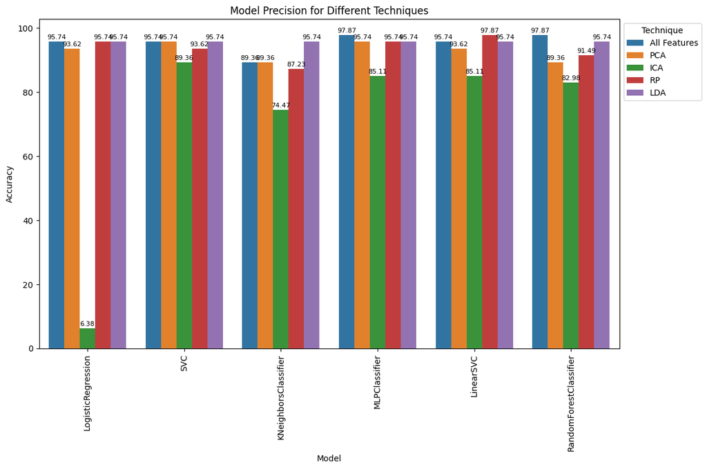

```python
plot_graph(df_final_,  metrics='Precision')
```

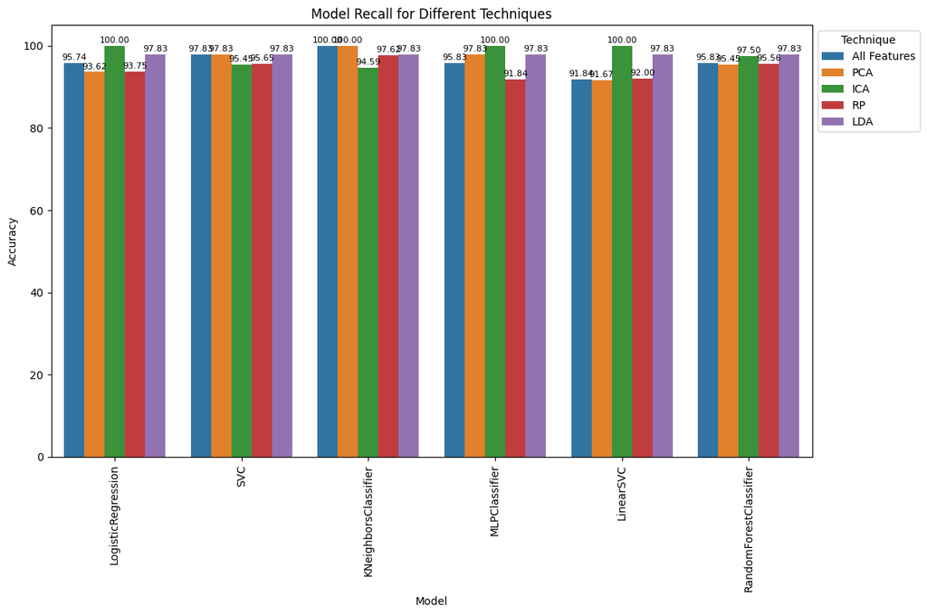

```python
plot_graph(df_final_,  metrics='Recall')
```

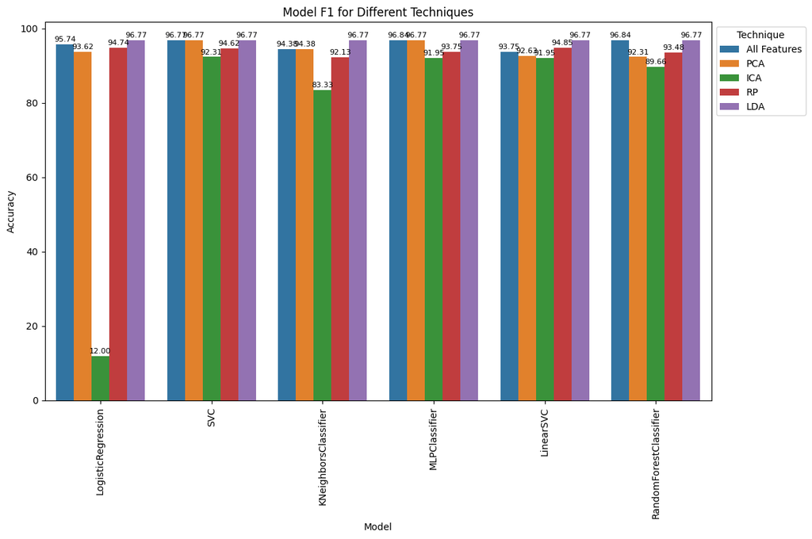

```python
plot_graph(df_final_,  metrics='F1')
```

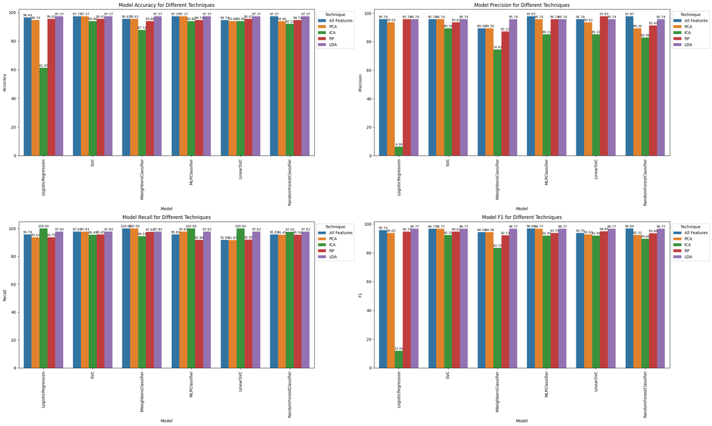

```python
# Metrics to plot
metrics = ['Accuracy', 'Precision', 'Recall', 'F1']

# Creating subplots for each metric
fig, axes = plt.subplots(nrows=2, ncols=2, figsize=(25, 15))

for i, metric in enumerate(metrics):
    row = i // 2
    col = i % 2
    ax = sns.barplot(x='Model', y=metric, hue='Technique', data=df_final_, ax=axes[row, col])

    # Annotate with count text
    for p in ax.patches:
        ax.annotate(f'{p.get_height():.2f}',
                    (p.get_x() + p.get_width() / 2., p.get_height()),
                    ha='center', va='center', fontsize=8, color='black', xytext=(0, 5),
                    textcoords='offset points')

    ax.set_xlabel('Model')
    ax.set_ylabel(metric)
    ax.set_title(f'Model {metric} for Different Techniques')
    ax.set_xticklabels(ax.get_xticklabels(), rotation=90)
    ax.legend(title='Technique', bbox_to_anchor=(1, 1), loc='upper left')

plt.tight_layout()
plt.show()
```